# Reproducible Research: Peer Assessment 1

pi-georgia

September 14, 2015

# Overview

It is now possible to collect a large amount of data about personal movement using activity monitoring devices. This assignment makes use of data from a personal activity monitoring device that collects data at 5 minute intervals through out the dayand investigates:  
1. investigates daily activity pattern.  
2. evaluates impact of missing data.  
3. compares activity pattern in weekdays versus weekands.  
*The data consists of two months of data from an anonymous individual collected during the months of October and November, 2012 and include the number of steps taken in 5 minute intervals each day.*

### Loading and preprocessing the data

```r
dataset <- read.csv("activity.csv")
```

### Mean total number of steps taken per day

First I will calculate the total number of steps taken each day and plot a histogram of the total number of steps taken each day. Then I will calculate and report the **mean** and **median** total number of steps taken per day

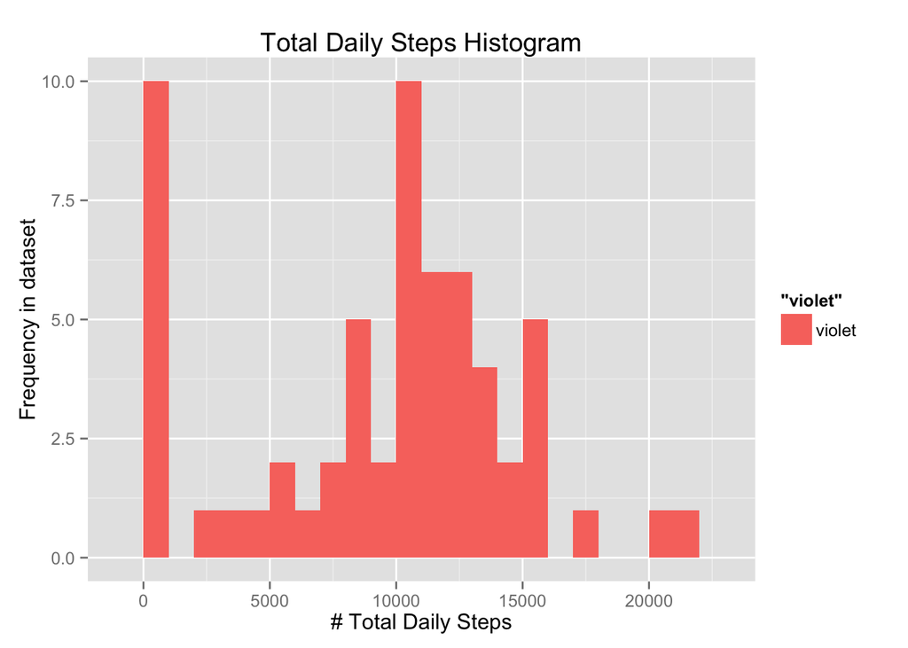

```r
library(dplyr)
daily <- group_by(dataset, date)
#calculate sums of steps by date
dailysum<- summarize(daily,total_steps= sum(steps, na.rm=TRUE))
#make a histogram : I will choose a binwidth that is at a scale relevant to the daily sum of steps, by choice 1000
library(ggplot2)
ggplot(dailysum, aes(x=total_steps, fill='violet')) + geom_histogram(binwidth =1000) +labs( title="Total Daily Steps Histogram", y="Frequency in dataset", x="# Total Daily Steps")
```

```r
mn<- mean(dailysum$total_steps) ; mn<- round(mn, 2)
md<- median(dailysum$total_steps)
```

The mean number of steps taken each day is **9354.23** and the median number of steps taken each day is **10395**.

### Average daily activity pattern

To visualize the daily activity pattern, here is a time series plot of the 5-minute interval (x-axis) and the average number of steps taken, averaged across all days (y-axis).

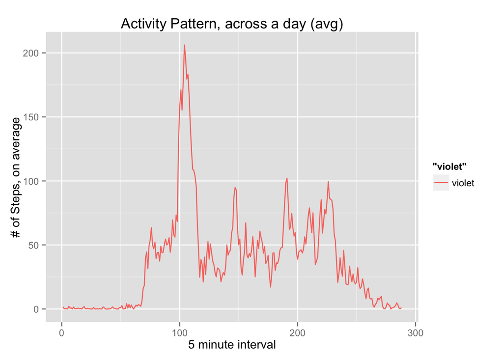

```r
interval <- group_by(dataset,as.factor( interval)) %>% summarize(daily_avg_steps=mean(steps, na.rm=TRUE))
names(interval)[1]<-"interval_class"
qplot(as.integer(interval$interval_class), interval$daily_avg_steps,main="Activity Pattern, across a day (avg)", ylab="# of Steps, on average", col= "violet",geom="line", xlab="5 minute interval" )
```

```r
max_act_int<- interval$interval_class[interval$daily_avg_steps==max(interval$daily_avg_steps)]
```

The 5-minute interval that on average across all the days in the dataset contains the maximum number of steps is  
the **835 th**

### Handling missing values (NAs)

To exclude bias introduced by NAs, I will clean-up my missing values after calculating how many of them exist.

```r
x<- sum(is.na(dataset))
```

There are **2304** missing values in my dataset.

To fill in all of the missing values in the dataset, I will use the daily mean to fill-in the missing data. To do so I will indentify NA position and replace their value with the mean of the day from the respective daily mean table.

```r
#get the indexes where NAs are located in the dataset, "index"
index<- which(is.na(dataset)) ; i<-1
dailymean<- summarize(daily,avg_steps= mean(steps, na.rm=TRUE))
# are there any NAs still remaining in the table of means? Making an index with NA positions in the dataframe of daily means, "index2"
index2<- which(is.na(dailymean[,2]))
# yes, so I will replace them with 0
dailymean[index2,2]<-0
#start building the timeseries where NAs are replaced with daily mean values
timeseries<-dataset
for (i in 1:length(index))
  {
#making an temporary index ("index3") to match the date for every NA measurement and get the mean for it from the relevant table
    index3<-  which(timeseries[index[i],2]==dailymean$date)
    timeseries[index[i],1]<-dailymean[index3,2]
   }
```

### Re-evaluate mean and median of total steps per day

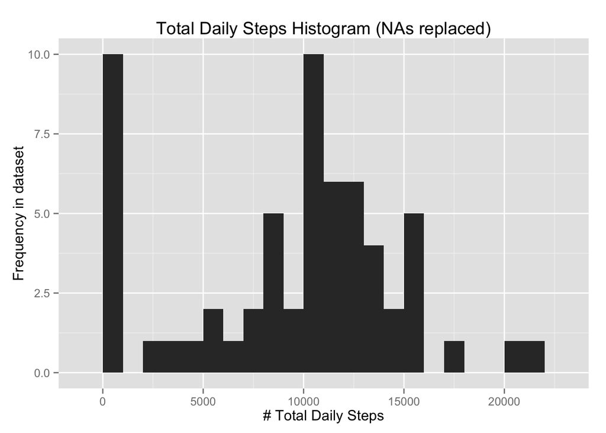

```r
total_timeseries<- group_by(timeseries, date=as.factor(date)) %>% summarize(total_steps=sum(steps, na.rm=TRUE))
ggplot(total_timeseries, aes(x=total_steps)) + geom_histogram(binwidth =1000) +labs( title="Total Daily Steps Histogram (NAs replaced)", y="Frequency in dataset", x="# Total Daily Steps")
```

```r
#Calculate new mean/median and their % change vs previous values
mnn<- mean(total_timeseries$total_steps) ; mdn<- median(total_timeseries$total_steps)
mean_change<- (mnn/mn-1)*100 ; median_change<- (mdn/md-1)*100
```

### Activity patterns comparison between weekdays and weekends

To understand if there are any **differences in activity patters between weekdays and weekends**, first I will manipulate my dataset, regrouping the steps by a new factor variable with two levels – “weekday” and “weekend” mapped on the dates.  
Then I will make a panel plot containing a time series plot of the 5-minute interval (x-axis) and the average number of steps taken, averaged across all weekday days or weekend days (y-axis).

[figure not shown]

```r
#remake my data set
WE <-c("Saturday", "Sunday")
w_series<- mutate(timeseries, weekday= weekdays(as.Date(date)), w_class = factor(1*(weekday %in% WE), labels=c("weekend", "weekday")))
ww<- group_by(w_series, w_class=as.factor(w_class), interval=as.factor(interval)) %>% summarize(avg_steps=mean(steps, na.rm=TRUE))

# Plot the activity patterns
ggplot(data=ww,aes(x=as.integer(interval),y=avg_steps)) + facet_wrap(~w_class, scales="free",  nrow = 2)+geom_line() + labs( title="Activity Patterns", y="Frequency in dataset", x="# average steps")
```